# Polynomial Linear Regression

### Import Libraries

```python
import pandas as pd
import numpy as np

# Plotting
import matplotlib.pyplot as plt
import seaborn as sns


# Documentation
import handcalcs.render

# Plot
%matplotlib inline
import matplotlib.pyplot as plt
from matplotlib import colors

from matplotlib import cm # color map
import seaborn as sns
import plotly.express as px

# Importing detect_outliers function from datasist library
from datasist.structdata import detect_outliers


from sympy import Sum, symbols, Indexed, lambdify, diff
from mpl_toolkits.mplot3d.axes3d import Axes3D

from sklearn.model_selection import train_test_split, cross_val_score
from sklearn.compose import ColumnTransformer
from sklearn.linear_model import LinearRegression, SGDRegressor
from sklearn.metrics import mean_absolute_error, mean_squared_error, r2_score
from sklearn.preprocessing import StandardScaler, LabelEncoder, OneHotEncoder, PolynomialFeatures

import statsmodels.api as sm
from statsmodels.stats.outliers_influence import variance_inflation_factor
from statsmodels.tools.tools import add_constant
```

```python
# Path
data_path = './Data/'
```

```python
raw_data = pd.read_csv(data_path+"Fish.csv",  low_memory=False).reset_index(drop=True)
raw_data.shape
```

```
(159, 7)
```

```python
raw_data
```

|  | Species | Weight | Length1 | Length2 | Length3 | Height | Width |
| --- | --- | --- | --- | --- | --- | --- | --- |
| 0 | Bream | 242.0 | 23.2 | 25.4 | 30.0 | 11.5200 | 4.0200 |
| 1 | Bream | 290.0 | 24.0 | 26.3 | 31.2 | 12.4800 | 4.3056 |
| 2 | Bream | 340.0 | 23.9 | 26.5 | 31.1 | 12.3778 | 4.6961 |
| 3 | Bream | 363.0 | 26.3 | 29.0 | 33.5 | 12.7300 | 4.4555 |
| 4 | Bream | 430.0 | 26.5 | 29.0 | 34.0 | 12.4440 | 5.1340 |
| ... | ... | ... | ... | ... | ... | ... | ... |
| 154 | Smelt | 12.2 | 11.5 | 12.2 | 13.4 | 2.0904 | 1.3936 |
| 155 | Smelt | 13.4 | 11.7 | 12.4 | 13.5 | 2.4300 | 1.2690 |
| 156 | Smelt | 12.2 | 12.1 | 13.0 | 13.8 | 2.2770 | 1.2558 |
| 157 | Smelt | 19.7 | 13.2 | 14.3 | 15.2 | 2.8728 | 2.0672 |
| 158 | Smelt | 19.9 | 13.8 | 15.0 | 16.2 | 2.9322 | 1.8792 |

159 rows × 7 columns

```python
columns = raw_data.columns
columns
```

```
Index(['Species', 'Weight', 'Length1', 'Length2', 'Length3', 'Height',
       'Width'],
      dtype='object')
```

```python
raw_data.info()
```

```
<class 'pandas.core.frame.DataFrame'>
RangeIndex: 159 entries, 0 to 158
Data columns (total 7 columns):
 #   Column   Non-Null Count  Dtype
---  ------   --------------  -----
 0   Species  159 non-null    object
 1   Weight   159 non-null    float64
 2   Length1  159 non-null    float64
 3   Length2  159 non-null    float64
 4   Length3  159 non-null    float64
 5   Height   159 non-null    float64
 6   Width    159 non-null    float64
dtypes: float64(6), object(1)
memory usage: 8.8+ KB
```

```python
raw_data.describe()
```

|  | Weight | Length1 | Length2 | Length3 | Height | Width |
| --- | --- | --- | --- | --- | --- | --- |
| count | 159.000000 | 159.000000 | 159.000000 | 159.000000 | 159.000000 | 159.000000 |
| mean | 398.326415 | 26.247170 | 28.415723 | 31.227044 | 8.970994 | 4.417486 |
| std | 357.978317 | 9.996441 | 10.716328 | 11.610246 | 4.286208 | 1.685804 |
| min | 0.000000 | 7.500000 | 8.400000 | 8.800000 | 1.728400 | 1.047600 |
| 25% | 120.000000 | 19.050000 | 21.000000 | 23.150000 | 5.944800 | 3.385650 |
| 50% | 273.000000 | 25.200000 | 27.300000 | 29.400000 | 7.786000 | 4.248500 |
| 75% | 650.000000 | 32.700000 | 35.500000 | 39.650000 | 12.365900 | 5.584500 |
| max | 1650.000000 | 59.000000 | 63.400000 | 68.000000 | 18.957000 | 8.142000 |

```python
raw_data.nunique()
```

```
Species      7
Weight     101
Length1    116
Length2     93
Length3    124
Height     154
Width      152
dtype: int64
```

### Finding for missing values

```python
raw_data.isnull().sum()
```

```
Species    0
Weight     0
Length1    0
Length2    0
Length3    0
Height     0
Width      0
dtype: int64
```

```python
for column in raw_data.columns:
    if column in ['Species']:
        print("-------------------------------------------------",column," - ",len(raw_data[column].unique()),"---------------------------------------------------")
        print(raw_data[column].unique())
        print("--------------------------------------------------------------------------------------------------------------")
```

```
------------------------------------------------- Species  -  7 ---------------------------------------------------
['Bream' 'Roach' 'Whitefish' 'Parkki' 'Perch' 'Pike' 'Smelt']
--------------------------------------------------------------------------------------------------------------
```

```python
raw_data.Species.value_counts()
```

```
Perch        56
Bream        35
Roach        20
Pike         17
Smelt        14
Parkki       11
Whitefish     6
Name: Species, dtype: int64
```

### Data Exploration

```python
# Setting seaborn visualization parameters
sns.set(rc={"figure.figsize" : [15,8]}, font_scale=1.2)
sns.set(rc={"axes.facecolor":"#F2F3F4","figure.facecolor":"#F2F3F4"})
palette = ["#F08080", "#FA8072", "#E9967A", "#FFA07A", "#CD5C5C", "#AF601A", "#CA6F1E"]
sns.set_palette(palette)
color_map = colors.ListedColormap(palette)
```

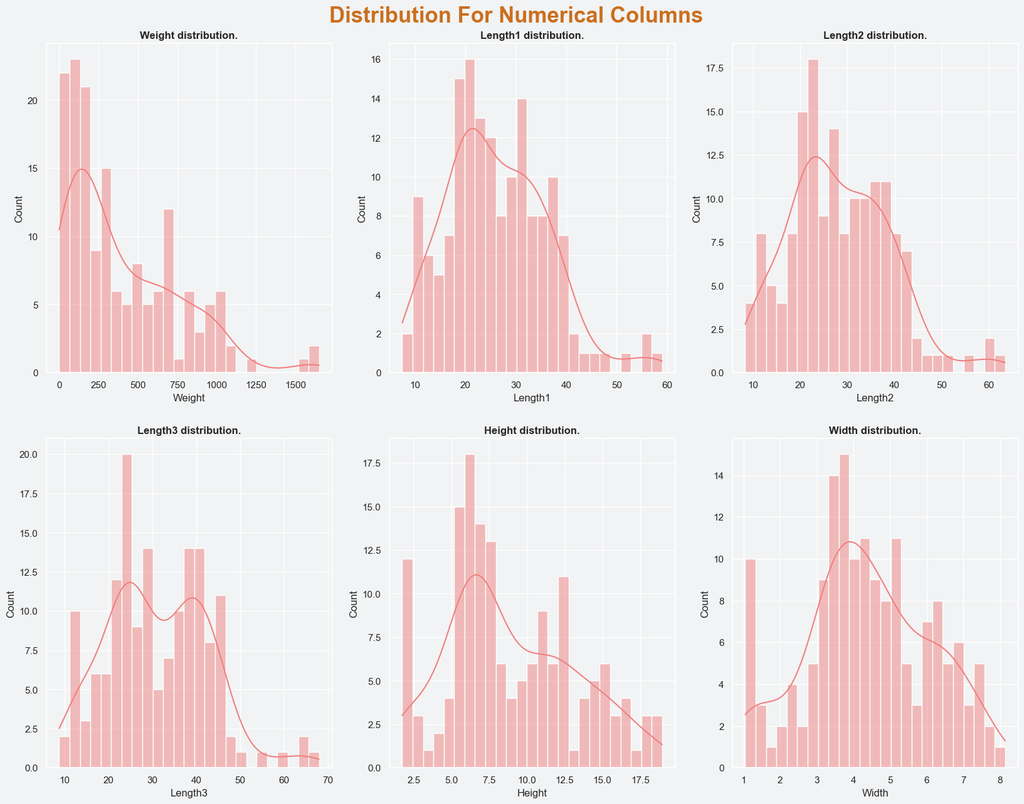

```python
## Extracting numerical columns from the 'fish' DataFrame
numerical_columns = raw_data.select_dtypes(include="number").columns.to_list()
## fig. size
plt.figure(figsize=(20, 15))

## Looping through each numerical column for plotting
for idx, column in enumerate(numerical_columns):

    ## Creating subplots within the grid
    plt.subplot(2, 3, idx+1)

    ## Plotting histogram with KDE for the current numerical column
    sns.histplot(data=raw_data,
                 x=column,
                 bins=25,
                 kde=True)

    ## title for the subplot
    plt.title(f"{column} distribution.", weight="bold")

## overall title
plt.suptitle("Distribution for Numerical Columns".title(), weight="bold", fontsize=25, x=0.5, y=0.92, color="#CA6F1E")

## Displaying the plot
plt.show()
```

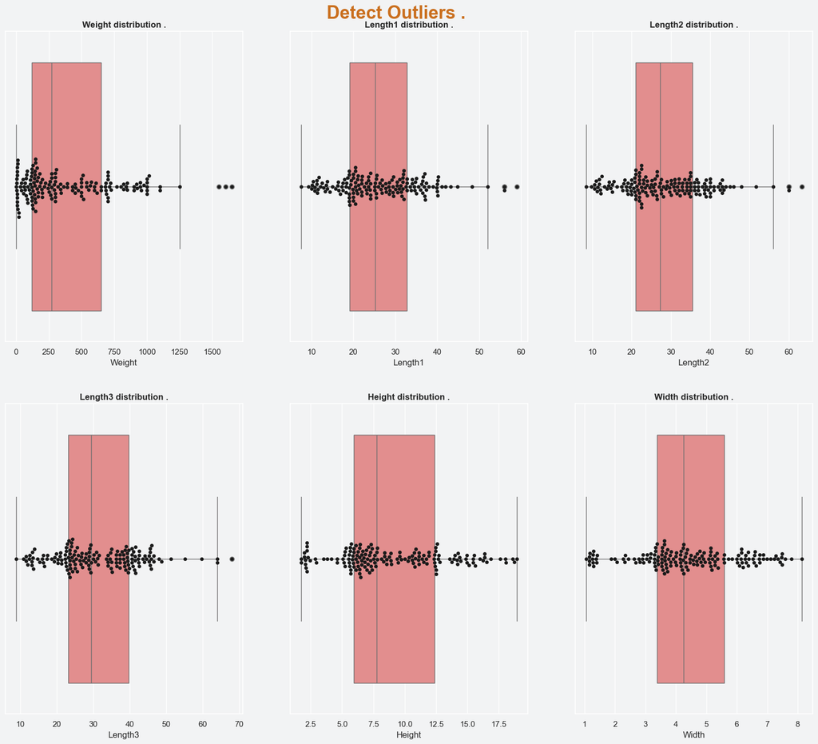

```python
plt.figure(figsize=(20, 17))

for idx, column in enumerate(numerical_columns):
    plt.subplot(2, 3, idx+1)
    sns.boxplot(data=raw_data, x=column)
    sns.swarmplot(data=raw_data, x=column, color="k")
    plt.title(f"{column} distribution .", weight="bold")
plt.suptitle("Detect Outliers .".title(), weight="bold", fontsize=25, x=0.5, y=0.91, color="#CA6F1E")
plt.show()
```

```python
# Detect Outliers Using datasist library¶

idx = detect_outliers(
    data=raw_data,
    n=0, ## the bench mark for the number of allowable outliers in the columns.
    features=['Weight', 'Length1', 'Length2', 'Length3']
)
```

```python
raw_data.iloc[idx]
```

|  | Species | Weight | Length1 | Length2 | Length3 | Height | Width |
| --- | --- | --- | --- | --- | --- | --- | --- |
| 142 | Pike | 1600.0 | 56.0 | 60.0 | 64.0 | 9.600 | 6.144 |
| 143 | Pike | 1550.0 | 56.0 | 60.0 | 64.0 | 9.600 | 6.144 |
| 144 | Pike | 1650.0 | 59.0 | 63.4 | 68.0 | 10.812 | 7.480 |

### Encoding categorical data

Encoding categorical data is a crucial step in preparing data for machine learning models, as many algorithms require numerical input. Categorical data represents variables that can take on a limited, and usually fixed, number of values. There are several common techniques for encoding categorical data:

1. Label Encoding:
   - Assigns a unique integer to each category.
   - Suitable for ordinal data where the order matters.
   - Sklearn provides LabelEncoder for this purpose.
2. One-Hot Encoding:
   - Creates binary columns for each category and represents the presence of a category with a 1.
   - Suitable for nominal data where there is no inherent order.
3. Ordinal Encoding:
   - Manually assign numerical values based on the order of categories.
   - Useful when there is an inherent order among categories.
4. Binary Encoding:
   - Converts categories into binary code.
   - Reduces the number of columns compared to one-hot encoding.
5. Hashing Encoding:
   - Converts categories into a fixed-size hash, useful when dealing with high cardinality.

```python
raw_data.describe(exclude="number")
```

|  | Species |
| --- | --- |
| count | 159 |
| unique | 7 |
| top | Perch |
| freq | 56 |

```python
raw_data["Species"].value_counts(normalize=True).to_frame()
```

|  | Species |
| --- | --- |
| Perch | 0.352201 |
| Bream | 0.220126 |
| Roach | 0.125786 |
| Pike | 0.106918 |
| Smelt | 0.088050 |
| Parkki | 0.069182 |
| Whitefish | 0.037736 |

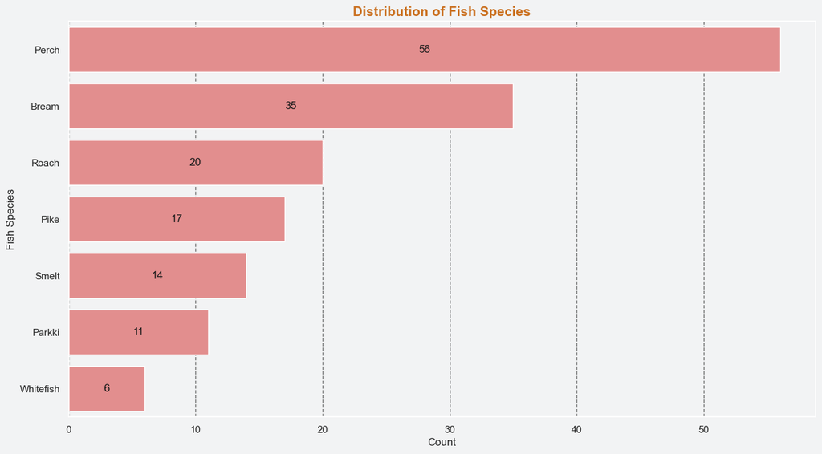

```python
## Create a count plot for the "Species" column
ax = sns.countplot(data=raw_data, y="Species", order=raw_data["Species"].value_counts().index)

## Add counts on top of each bar
for container in ax.containers:
    ax.bar_label(container, label_type="center", color="k")

## Add title and labels
plt.title("Distribution of Fish Species", fontsize=15, weight="bold", color="#CA6F1E")
plt.xlabel("Count")
plt.ylabel("Fish Species")
plt.grid(axis="x", linestyle="--", alpha=0.6, c="k")

## Show plot
plt.show()
```

### Bivariate Analysis & Multivariate Analysis .

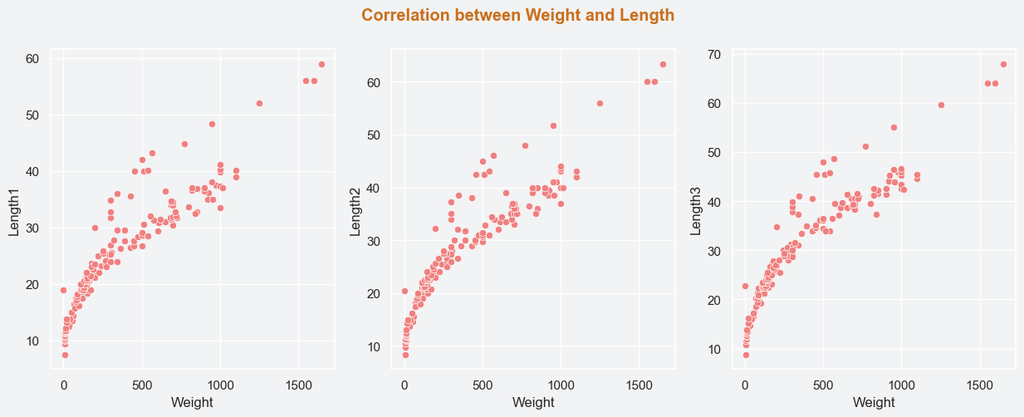

```python
condition = raw_data.columns.str.contains("Length")
all_length = raw_data.columns[condition].tolist()
plt.figure(figsize=(15,5))

for idx, column in enumerate(all_length):

    plt.subplot(1, 3, idx+1)
    sns.scatterplot(data=raw_data, x="Weight", y=column)
plt.suptitle("Correlation between Weight and Length", weight="bold", color="#CA6F1E")
plt.show()
```

```python
raw_data[["Length1", "Length2", "Length3", "Weight"]].corr()
```

|  | Length1 | Length2 | Length3 | Weight |
| --- | --- | --- | --- | --- |
| Length1 | 1.000000 | 0.999517 | 0.992031 | 0.915712 |
| Length2 | 0.999517 | 1.000000 | 0.994103 | 0.918618 |
| Length3 | 0.992031 | 0.994103 | 1.000000 | 0.923044 |
| Weight | 0.915712 | 0.918618 | 0.923044 | 1.000000 |

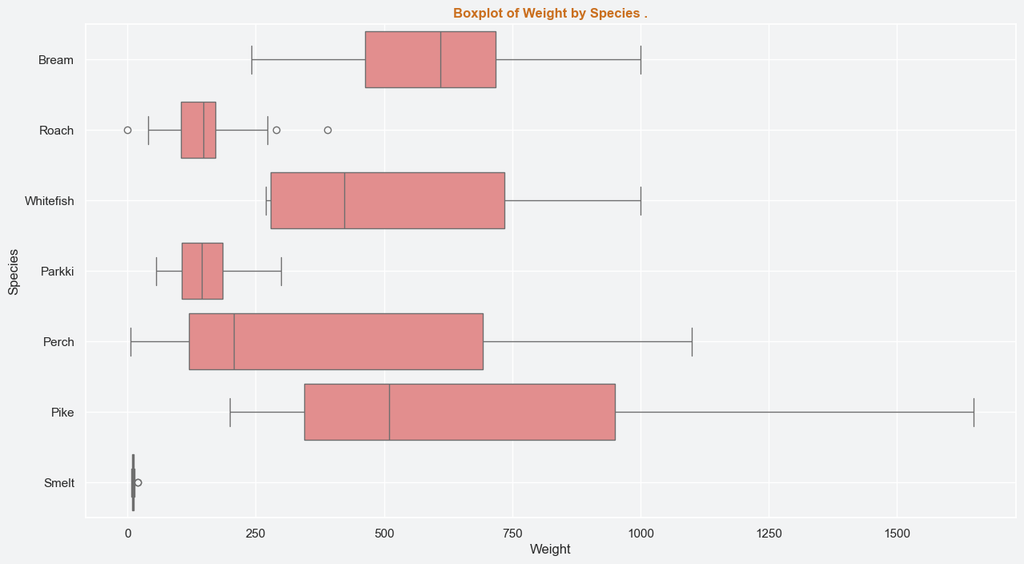

```python
sns.boxplot(data=raw_data, x="Weight", y="Species")
plt.title('Boxplot of Weight by Species .', weight="bold", color="#CA6F1E")
plt.xlabel('Weight')
plt.ylabel('Species')
plt.grid(True)
plt.show()
```

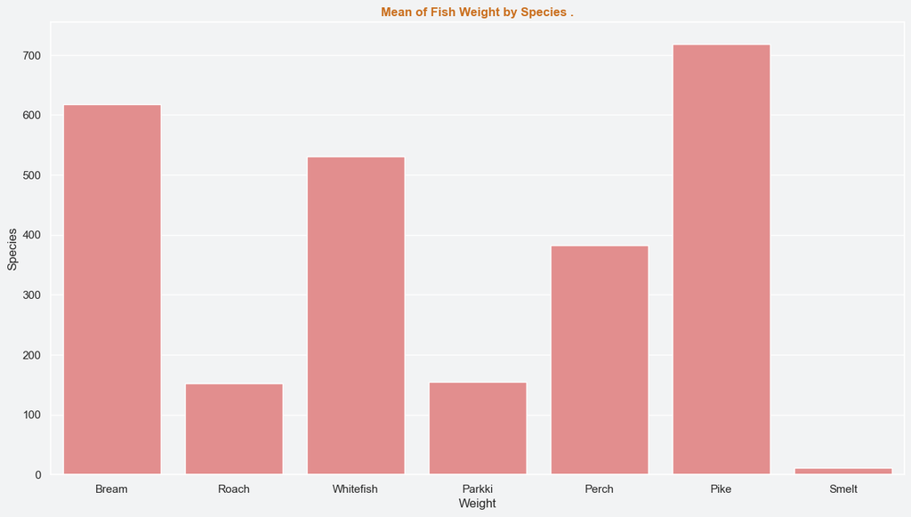

```python
## Create barplot using seaborn between species and the mean of weight
sns.barplot(
    data=raw_data,
    x="Species",
    y="Weight",
    errorbar=('ci', False),
    estimator='mean'
)

## title and labels name
plt.title('Mean of Fish Weight by Species .', weight="bold", color="#CA6F1E")
plt.xlabel('Weight')
plt.ylabel('Species')

## Show plot
plt.show()
plt.show()
```

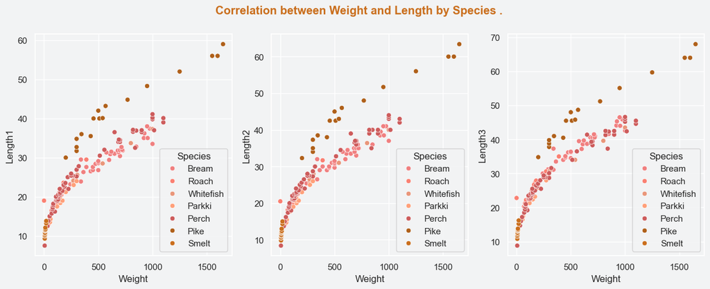

```python
plt.figure(figsize=(15,5))

for idx, column in enumerate(all_length):

    plt.subplot(1, 3, idx+1)
    sns.scatterplot(data=raw_data, x="Weight", y=column, hue="Species")
plt.suptitle("Correlation between Weight and Length by Species .", weight="bold", color="#CA6F1E")
plt.show()
```

```python
raw_data[["Height", "Width"]].corr()
```

|  | Height | Width |
| --- | --- | --- |
| Height | 1.000000 | 0.792881 |
| Width | 0.792881 | 1.000000 |

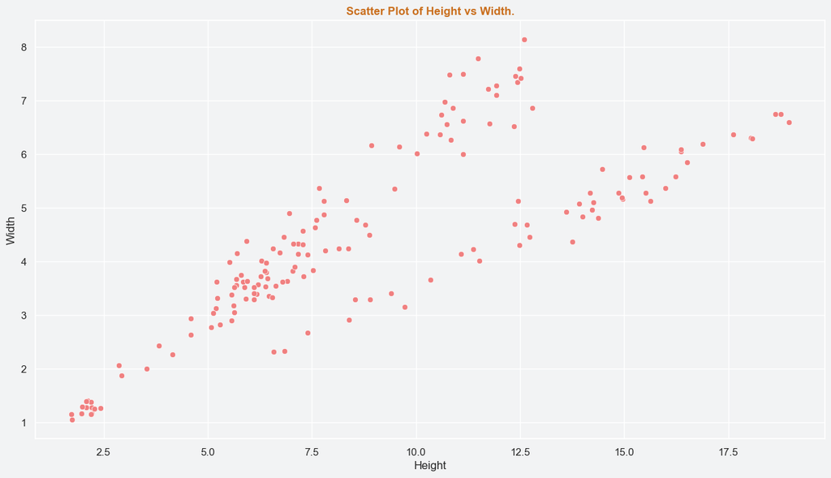

```python
sns.scatterplot(data=raw_data, x="Height", y="Width")
plt.title('Scatter Plot of Height vs Width.', weight="bold", color="#CA6F1E")
plt.xlabel('Height')
plt.ylabel('Width')
plt.grid(True)
plt.show()
```

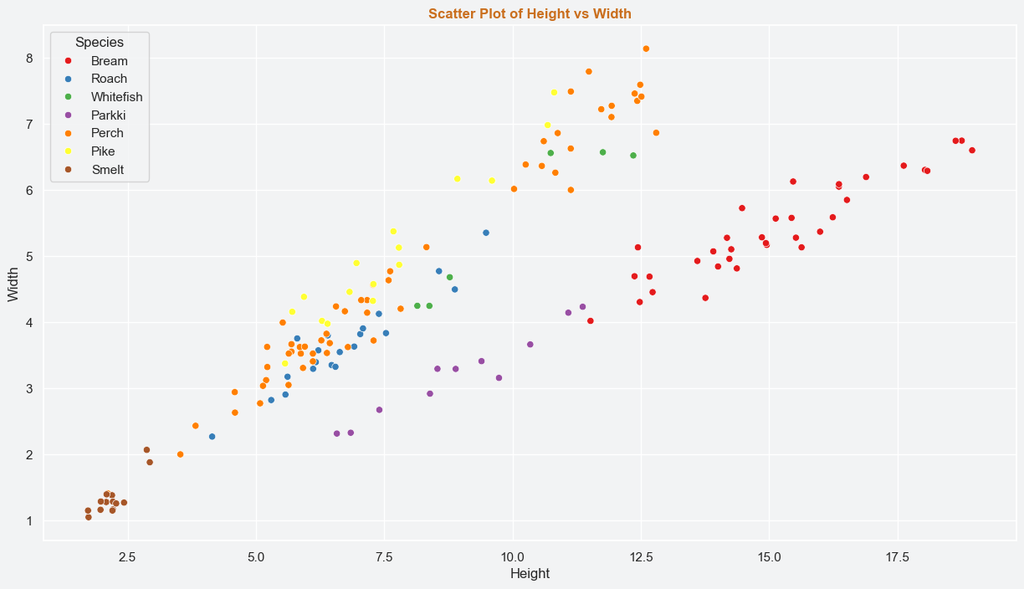

```python
sns.scatterplot(data=raw_data, x="Height", y="Width", hue="Species", palette="Set1")
plt.title('Scatter Plot of Height vs Width', weight="bold", color="#CA6F1E")
plt.xlabel('Height')
plt.ylabel('Width')
plt.grid(True)
plt.show()
```

```python
## Selecting rows where the species is "Pike" and extracting columns "Height" and "Width"
pike_data = raw_data[raw_data["Species"] == "Pike"][["Height", "Width"]]

## Calculating the correlation coefficient between the height and width of Pike
corr_coeff = pike_data.corr().iloc[0, 1].round(2)
print(f"correlation between height and width for pike type : {corr_coeff}")
```

```
correlation between height and width for pike type : 0.97
```

```python
## Selecting rows where the species is "Pike" and extracting columns "Height" and "Width"
pike_data = raw_data[raw_data["Species"] == "Smelt"][["Height", "Width"]]

## Calculating the correlation coefficient between the height and width of Pike
corr_coeff = pike_data.corr().iloc[0, 1].round(2)
print(f"correlation between height and width for smelt type : {corr_coeff}")
```

```
correlation between height and width for smelt type : 0.87
```

```python
raw_data[["Length1", "Length2", "Length3", "Height"]].corr()[["Height"]]
```

|  | Height |
| --- | --- |
| Length1 | 0.625378 |
| Length2 | 0.640441 |
| Length3 | 0.703409 |
| Height | 1.000000 |

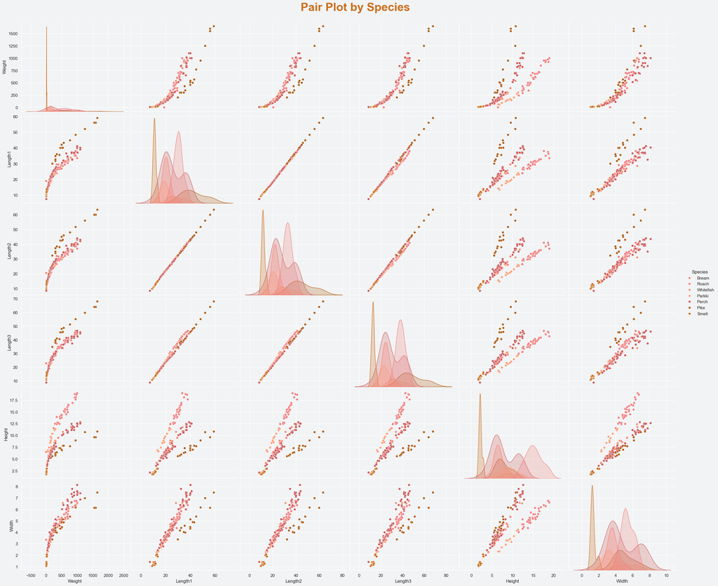

```python
pair_plot = sns.pairplot(
    data=raw_data,
    hue="Species",
    diag_kind="kde",  # Use kernel density estimates on diagonal plots
    height=3.5,  # Set the height of each subplot
    aspect=1.2  # Adjust the aspect ratio of the subplots
)
pair_plot.fig.suptitle("Pair Plot by Species", y=1.02, fontsize=30, weight="bold", color="#CA6F1E")
plt.show()
```

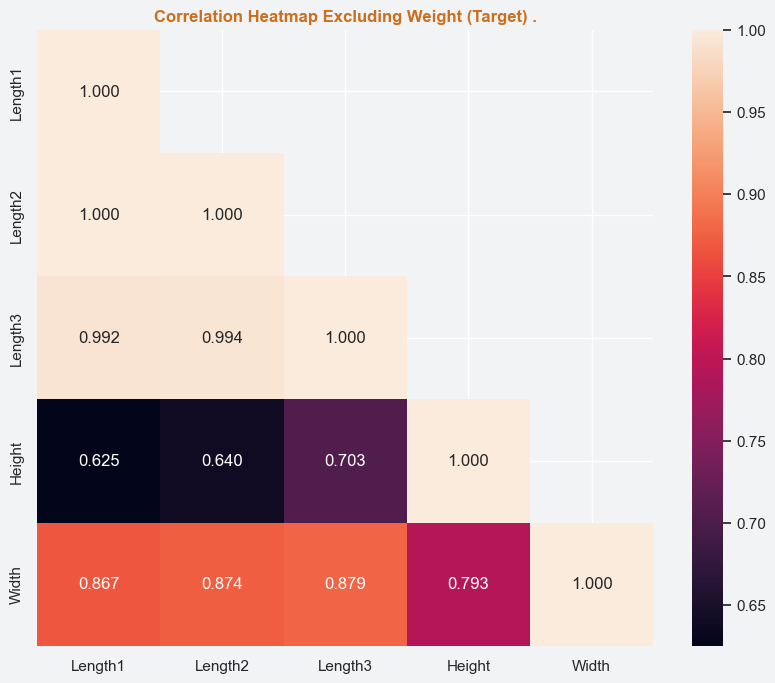

```python
## Calculate the correlation matrix, excluding the 'Weight' column (target)
multi_corr = raw_data.drop("Weight", axis=1).corr(numeric_only=True)

## Create a mask for the upper triangle to hide it
mask = np.triu(np.ones_like(multi_corr), k=1)

## figure size
plt.figure(figsize=(10, 8))

## heatmap using seaborn
sns.heatmap(
    multi_corr,
    annot=True,       # Display the correlation values
    mask=mask,        # Apply the mask to hide the upper triangle
    square=True,       # Ensure square-shaped cells
    fmt="0.3f"
)

## title of the heatmap
plt.title("Correlation Heatmap Excluding Weight (Target) .", weight="bold", color="#CA6F1E")

## Show the plot
plt.show()
```

```python
## Drop Columns with multucollinearlity
raw_data.drop(columns=["Length2", "Length3"], inplace=True)
```

```python
target = "Weight"
x_variables = raw_data.drop(target, axis=1)
y_variables = pd.DataFrame(raw_data[target])
```

```python
### Split Data - train, test
X_train, X_test, y_train, y_test = train_test_split(x_variables, y_variables, test_size=0.2, random_state = 10)
```

```python
print("X_train Size :",len(X_train))
print("Y_train Size :",len(y_train))
print("X_test Size :",len(X_test))
print("Y_test Size :",len(y_test))
print("Train Size :", (len(X_train)/len(x_variables))*100)
print("Train Size :", (len(X_test)/len(x_variables))*100)
```

```
X_train Size : 127
Y_train Size : 127
X_test Size : 32
Y_test Size : 32
Train Size : 79.87421383647799
Train Size : 20.125786163522015
```

```python
num_feat = x_variables.select_dtypes(include="number").columns.to_list()
categ_feat = y_variables.select_dtypes(exclude="number").columns.to_list()
print("After addressing multicollinearity, the remaining columns are:")
print(f"Numerical Feature in the Data ==> {num_feat}")
print(f"Categorical Feature in the Data ==> {categ_feat}")
```

```
After addressing multicollinearity, the remaining columns are:
Numerical Feature in the Data ==> ['Length1', 'Height', 'Width']
Categorical Feature in the Data ==> []
```

```python
## Create a ColumnTransformer for preprocessing numerical and categorical features

preprocess_cols = ColumnTransformer([
    ("Numerical Cols", StandardScaler(), num_feat),
    ("Categorical Cols", OneHotEncoder(), categ_feat)
])

## Fit the ColumnTransformer on the training data..
preprocess_cols.fit(X_train)

## Transform the training and test data using the fitted ColumnTransformer
X_train_final = preprocess_cols.transform(X_train)
X_test_final = preprocess_cols.transform(X_test)
```

```python
## Create an instance of the LinearRegression model
lin_reg = LinearRegression()

## Fit the model to the training data
## X_train_final: Features of the training set
## y_train: Target values of the training set
lin_reg.fit(X_train_final, y_train)
```

```
LinearRegression()
```

```python
## Predictions on the training set using the trained Linear Regression model
lin_reg_train_predict = lin_reg.predict(X_train_final)
## Predictions on the testing set using the trained Linear Regression model
lin_reg_test_predict = lin_reg.predict(X_test_final)

## Mean Squared Error (MSE) for the training data
print(f"MSE For Training Data (Linear Reg.) : {mean_squared_error(y_train, lin_reg_train_predict).round(2)}")
## Mean Squared Error (MSE) for the testing data
print(f"MSE For Testing Data (Linear Reg.) : {mean_squared_error(y_test, lin_reg_test_predict).round(2)}")
print("**" * 50)
## Mean Absolute Error (MAE) for the training data
print(f"MAE For Training Data (Linear Reg.) : {mean_absolute_error(y_train, lin_reg_train_predict).round(2)}")
## Mean Absolute Error (MAE) for the testing data
print(f"MAE For Testing Data (Linear Reg.) : {mean_absolute_error(y_test, lin_reg_test_predict).round(2)}")
print("**" * 50)
## R-squared score for the training data
print(f"R-Squere Score For Training Data (Linear Reg.) : {r2_score(y_train, lin_reg_train_predict).round(2) * 100} %")
## R-squared score for the testing data
print(f"R-Squere Score For Testing Data (Linear Reg.) : {r2_score(y_test, lin_reg_test_predict).round(2) * 100} %")
```

```
MSE For Training Data (Linear Reg.) : 16099.32
MSE For Testing Data (Linear Reg.) : 11054.92
MAE For Training Data (Linear Reg.) : 99.2
MAE For Testing Data (Linear Reg.) : 84.99
R-Squere Score For Training Data (Linear Reg.) : 89.0 %
R-Squere Score For Testing Data (Linear Reg.) : 71.0 %
```

```python
# Gradient Descent

## Create an instance of the SGDRegressor model with specific parameters
## penalty=None: No regularization penalty
## random_state=90: Seed for reproducibility
## learning_rate='constant': Constant learning rate
## eta0=0.01: Initial learning rate
SGD = SGDRegressor(
    penalty=None, random_state=90, learning_rate='constant', eta0=0.02, max_iter=1000
)

## Fit the model to the training data
## X_train_final: Features of the training set
## y_train: Target values of the training set
SGD.fit(X_train_final, y_train.iloc[:, 0].values)
```

```
SGDRegressor(eta0=0.02, learning_rate='constant', penalty=None, random_state=90)
```

```python
SGD_train_predict = SGD.predict(X_train_final)
SGD_test_predict = SGD.predict(X_test_final)

print(f"MSE For Training Data (SGD) : {mean_squared_error(y_train, SGD_train_predict).round(2)}")
print(f"MSE For Testing Data (SGD) : {mean_squared_error(y_test, SGD_test_predict).round(2)}")
print("**" * 50)
print(f"MAE For Training Data (SGD) : {mean_absolute_error(y_train, SGD_train_predict).round(2)}")
print(f"MAE For Testing Data (SGD) : {mean_absolute_error(y_test, SGD_test_predict).round(2)}")
print("**" * 50)
print(f"R-Square Score For Training Data (SGD) : {r2_score(y_train, SGD_train_predict).round(2) * 100} %")
print(f"R-Square Score For Testing Data (SGD) : {r2_score(y_test, SGD_test_predict).round(2) * 100} %")
```

```
MSE For Training Data (SGD) : 16156.4
MSE For Testing Data (SGD) : 11612.37
MAE For Training Data (SGD) : 99.49
MAE For Testing Data (SGD) : 86.94
R-Square Score For Training Data (SGD) : 89.0 %
R-Square Score For Testing Data (SGD) : 70.0 %
```

```python
# cross validation

results = cross_val_score(estimator=SGD, X=X_train_final, y=y_train.iloc[:, 0].values, scoring="r2", cv=5)

print(f'CV Score using R-Square: {results}')
print(f'Mean of Results: {results.mean().round(2) * 100} %')
print(f'SD of results: {results.std().round(4)}') ## Standard Deviation
```

```
CV Score using R-Square: [0.86903092 0.87879141 0.81720361 0.89172989 0.87064825]
Mean of Results: 87.0 %
SD of results: 0.0254
```

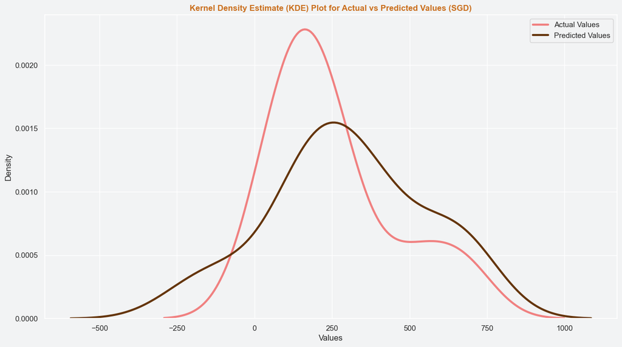

```python
# Create KDE plots
sns.kdeplot(data=y_test, linewidth=3, label='Actual Values')
sns.kdeplot(data=SGD_test_predict, linewidth=3, color="#64340A", label='Predicted Values')

# Set labels and title
plt.xlabel("Values")
plt.ylabel("Density")
plt.title("Kernel Density Estimate (KDE) Plot for Actual vs Predicted Values (SGD)", weight="bold", color="#CA6F1E")

# Display legend
plt.legend()

# Show the plot
plt.show()
```

```python
## Create an instance of PolynomialFeatures
poly = PolynomialFeatures(degree=2)
## Transform the features of the training set to include polynomial combinations
X_train_poly = poly.fit_transform(X_train_final)
## Transform the features of the testing set to include polynomial combinations
X_test_poly = poly.transform(X_test_final)
```

```python
poly_reg = LinearRegression()
poly_reg.fit(X_train_poly, y_train)
```

```
LinearRegression()
```

```python
poly_train_predict = poly_reg.predict(X_train_poly)
poly_test_predict = poly_reg.predict(X_test_poly)

print(f"MSE For Training Data (Polynomial Regression) : {mean_squared_error(y_train, poly_train_predict).round(2)}")
print(f"MSE For Testing Data (Polynomial Regression) : {mean_squared_error(y_test, poly_test_predict).round(2)}")
print("**" * 50)
print(f"MAE For Training Data (Polynomial Regression) : {mean_absolute_error(y_train, poly_train_predict).round(2)}")
print(f"MAE For Testing Data (Polynomial Regression) : {mean_absolute_error(y_test, poly_test_predict).round(2)}")
print("**" * 50)
print(f"R-Square Score For Training Data (Polynomial Regression) : {r2_score(y_train, poly_train_predict).round(2) * 100} %")
print(f"R-Square Score For Testing Data (Polynomial Regression) : {r2_score(y_test, poly_test_predict).round(2) * 100} %")
```

```
MSE For Training Data (Polynomial Regression) : 2594.66
MSE For Testing Data (Polynomial Regression) : 1385.32
MAE For Training Data (Polynomial Regression) : 34.22
MAE For Testing Data (Polynomial Regression) : 25.14
R-Square Score For Training Data (Polynomial Regression) : 98.0 %
R-Square Score For Testing Data (Polynomial Regression) : 96.0 %
```

```python
#  Cross Validation

results = cross_val_score(
    estimator=poly_reg, X=X_train_poly, y=y_train, scoring="r2", cv=5
)
print(f'CV Score using R-Square: {results}')
print(f'Mean of Results: {results.mean().round(2) * 100} %')
print(f'SD of results: {results.std().round(4)}') ## Standard Deviation
```

```
CV Score using R-Square: [0.97268534 0.97946351 0.95263976 0.98247351 0.96779586]
Mean of Results: 97.0 %
SD of results: 0.0105
```

[figure not shown]

```python
# Plotting the actual vs predicted values

# Create KDE plots
sns.kdeplot(data=y_test, linewidth=3, label='Actual Values')
sns.kdeplot(data=poly_test_predict, linewidth=3, color="#64340A", label='Predicted Values')

# Set labels and title
plt.xlabel("Values")
plt.ylabel("Density")
plt.title("Kernel Density Estimate (KDE) Plot for Actual vs Predicted Values (SGD)", weight="bold", color="#CA6F1E")

# Display legend
plt.legend()

# Show the plot
plt.show()
```